# Home Depot Product Search Relevance

March 13, 2016

## Agenda

- Overview
- Data Story
- Modeling
- Output Analysis

## Overview

- Home Depot Product Search Relevance is Kaggle competition targets to improve Home Depot customers' shopping experience.
- Target: developing a model that can accurately predict the relevance of search results.

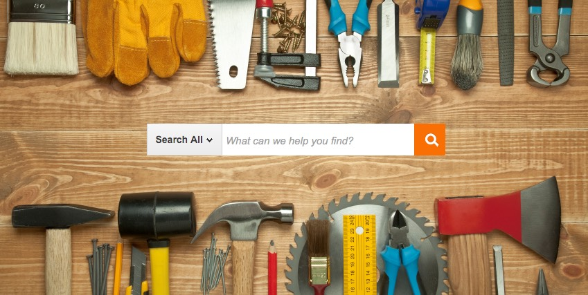

## Data Story

- This data set contains a number of products and real customer search terms from Home Depot's website.
- The challenge: to predict a relevance score for the provided combinations of search terms and products.
- The relevance is a number between **1** (not relevant) to **3** (highly relevant).

For example, a search for "AA battery" would be considered highly relevant to a pack of size AA batteries (relevance = 3), mildly relevant to a cordless drill battery (relevance = 2), and not relevant to a snow shovel (relevance = 1).

## Data Story Cont..

Data includes the following files:

- *train.csv* –> the training set, contains products, searches, and relevance scores.

```
## Observations: 74,067
## Variables: 5
## $ id            (int) 2, 3, 9, 16, 17, 18, 20, 21, 23, 27, 34, 35, 37,...
## $ product_uid   (int) 100001, 100001, 100002, 100005, 100005, 100006, ...
## $ product_title (chr) "Simpson Strong-Tie 12-Gauge Angle", "Simpson St...
## $ search_term   (chr) "angle bracket", "l bracket", "deck over", "rain...
## $ relevance     (dbl) 3.00, 2.50, 3.00, 2.33, 2.67, 3.00, 2.67, 3.00, ...
```

## Data Story Cont..

- Relevance Distribution

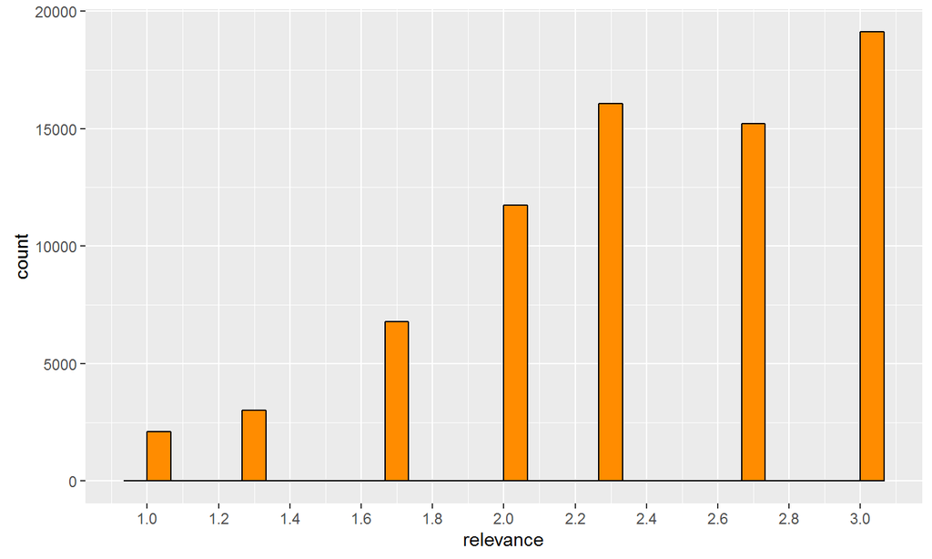

## Data Story Cont..

- Relevance Desnisty Function

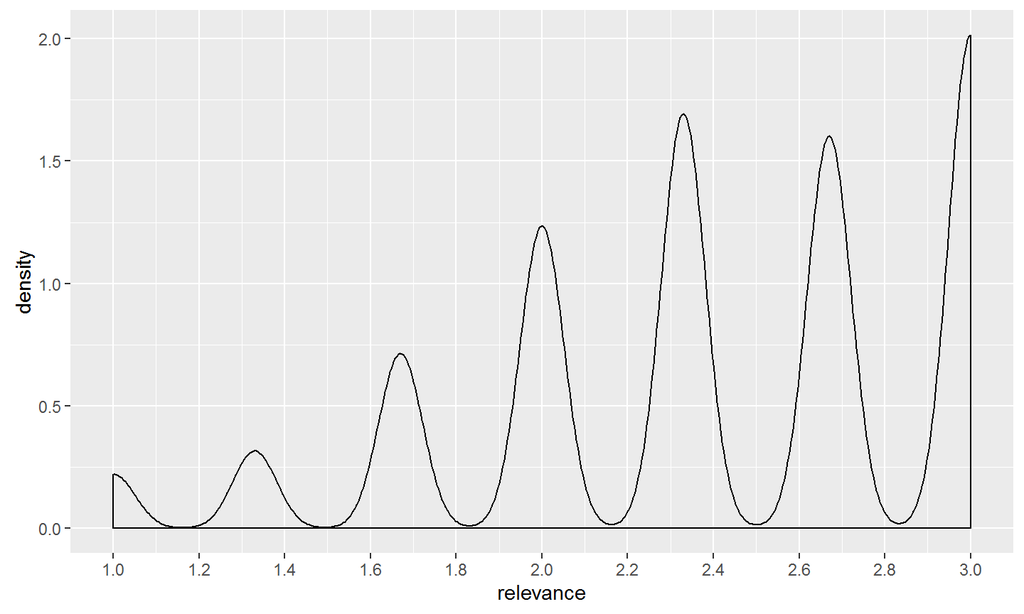

## Data Story Cont..

- *test.csv* –> similar to train.csv except the absence for relevance scores.
- *product_descriptions.csv* contains a text description of each product.

```
## Observations: 124,428
## Variables: 2
## $ product_uid         (int) 100001, 100002, 100003, 100004, 100005, 10...
## $ product_description (chr) "Not only do angles make joints stronger, ...
```

## Data Story Cont..

- Combined train, test and product desription data

```
## Observations: 240,760
## Variables: 6
## $ id                  (int) 2, 3, 1, 4, 5, 6, 7, 8, 9, 10, 11, 12, 13,...
## $ product_uid         (int) 100001, 100001, 100001, 100001, 100001, 10...
## $ product_title       (chr) "Simpson Strong-Tie 12-Gauge Angle", "Simp...
## $ search_term         (chr) "angle bracket", "l bracket", "90 degree b...
## $ relevance           (dbl) 3.00, 2.50, NA, NA, NA, NA, NA, NA, 3.00, ...
## $ product_description (chr) "Not only do angles make joints stronger, ...
```

## Data Story Cont..

- The most search terms used

```
## Source: local data frame [24,601 x 2]
##
##                  search_term     n
##                        (chr) (int)
## 1       patio chair cushions    36
## 2                        1x4    23
## 3             24 inch vanity    23
## 4    40 gal gas water heater    23
## 5                        4x6    23
## 6                    acrylic    23
## 7   air conditioner portable    23
## 8  air conditioner with heat    23
## 9      allure plank flooring    23
## 10     allure vinyl flooring    23
## ..                       ...   ...
```

## Data Story Cont..

- The most searched products

```
## Source: local data frame [124,428 x 2]
##
##    product_uid     n
##          (int) (int)
## 1       101892    70
## 2       101442    49
## 3       102456    48
## 4       101959    47
## 5       101280    45
## 6       102162    44
## 7       104691    44
## 8       101148    43
## 9       100898    42
## 10      109594    41
## ..         ...   ...
```

## Data Story Cont..

- *attributes.csv* provides extended information about a subset of the products (typically representing detailed technical specifications). Not every product is having attributes

```
## Observations: 2,044,803
## Variables: 3
## $ product_uid (int) 100001, 100001, 100001, 100001, 100001, 100001, 10...
## $ name        (chr) "Bullet01", "Bullet02", "Bullet03", "Bullet04", "B...
## $ value       (chr) "Versatile connector for various 90Â° connections ...
```

## Modeling

- *Step 1*: combine attributes keys and values

```
## Observations: 2,044,648
## Variables: 2
## $ product_uid (int) 100001, 100001, 100001, 100001, 100001, 100001, 10...
## $ property    (chr) "Bullet01;;Versatile connector for various 90Â° co...
```

## Modeling Cont…

- *Step 2*: group rows with the same id

```
## Observations: 86,263
## Variables: 2
## $ Group.1                      (int) 100001, 100002, 100003, 100004, 1...
## $ products_attributes$property (chr) "Bullet01;;Versatile connector fo...
```

## Modeling Cont…

- *Step 3*: restore original names

```
## Observations: 86,263
## Variables: 2
## $ product_uid (int) 100001, 100002, 100003, 100004, 100005, 100006, 10...
## $ property    (chr) "Bullet01;;Versatile connector for various 90Â° co...
```

## Modeling Cont…

- *Step 4*: Generate new attribute fields and combine with the main product set

```
## Observations: 240,760
## Variables: 12
## $ id                  (int) 2, 3, 1, 4, 5, 6, 7, 8, 9, 10, 11, 12, 13,...
## $ product_uid         (int) 100001, 100001, 100001, 100001, 100001, 10...
## $ product_title       (chr) "Simpson Strong-Tie 12-Gauge Angle", "Simp...
## $ search_term         (chr) "angle bracket", "l bracket", "90 degree b...
## $ relevance           (dbl) 3.00, 2.50, NA, NA, NA, NA, NA, NA, 3.00, ...
## $ product_description (chr) "Not only do angles make joints stronger, ...
## $ property            (chr) "Bullet01;;Versatile connector for various...
## $ bullets             (chr) "Versatile connector for various 90Â° conn...
## $ yeses               (chr) "", "", "", "", "", "", "", "", "Concrete ...
## $ nos                 (chr) "", "", "", "", "", "", "", "", "Sealer Ti...
## $ keys                (chr) "Gauge Material MFG Brand Name Number of P...
## $ values              (chr) "12 Galvanized Steel Simpson Strong-Tie 1 ...
```

## Modeling Cont…

- *Step 5*: Generate the features that is used in linear regression

[output not shown]

```
## Observations: 240,760
## Variables: 17
## $ id                  (int) 2, 3, 1, 4, 5, 6, 7, 8, 9, 10, 11, 12, 13,...
## $ product_uid         (int) 100001, 100001, 100001, 100001, 100001, 10...
## $ product_title       (chr) "Simpson Strong-Tie 12-Gauge Angle", "Simp...
## $ search_term         (chr) "angle bracket", "l bracket", "90 degree b...
## $ relevance           (dbl) 3.00, 2.50, NA, NA, NA, NA, NA, NA, 3.00, ...
## $ product_description (chr) "Not only do angles make joints stronger, ...
## $ property            (chr) "Bullet01;;Versatile connector for various...
## $ bullets             (chr) "Versatile connector for various 90Â° conn...
## $ yeses               (chr) "", "", "", "", "", "", "", "", "Concrete ...
## $ nos                 (chr) "", "", "", "", "", "", "", "", "Sealer Ti...
## $ keys                (chr) "Gauge Material MFG Brand Name Number of P...
## $ values              (chr) "12 Galvanized Steel Simpson Strong-Tie 1 ...
## $ bulletsScore        (dbl) 0.8333333, 0.8333333, 0.7777778, 0.7555556...
## $ yesesScore          (dbl) 0.0000000, 0.0000000, 0.0000000, 0.0000000...
## $ nosScore            (dbl) 0.0000000, 0.0000000, 0.0000000, 0.0000000...
## $ keysScore           (dbl) 0.5500000, 0.7500000, 0.3000000, 0.7000000...
## $ valuesScore         (dbl) 0.4428571, 0.6428571, 0.3952381, 0.5500000...
```

## Modeling Cont…

- *Step 6*: Divide the data into training and test sets so can perform prediction and test our model
- *Step 7*: Performing linear regression
- *Step 8*: Test model investigation

```
##
## Call:
## lm(formula = relevance ~ bulletsScore + yesesScore + nosScore +
##     keysScore + valuesScore, data = product_all_train)
##
## Residuals:
##      Min       1Q   Median       3Q      Max
## -1.54892 -0.35275  0.01231  0.53109  0.77971
##
## Coefficients:
##               Estimate Std. Error t value Pr(>|t|)
## (Intercept)   2.468907   0.003862 639.280  < 2e-16 ***
## bulletsScore -0.278528   0.012414 -22.436  < 2e-16 ***
## yesesScore    0.035908   0.011058   3.247 0.001166 **
## nosScore      0.040682   0.010579   3.846 0.000120 ***
## keysScore     0.056294   0.016768   3.357 0.000788 ***
## valuesScore   0.096021   0.012965   7.406 1.31e-13 ***
## ---
## Signif. codes:  0 '***' 0.001 '**' 0.01 '*' 0.05 '.' 0.1 ' ' 1
##
## Residual standard error: 0.5303 on 74061 degrees of freedom
## Multiple R-squared:  0.01389,    Adjusted R-squared:  0.01382
## F-statistic: 208.6 on 5 and 74061 DF,  p-value: < 2.2e-16
```

## Output Analysis

- Relevance Distribution

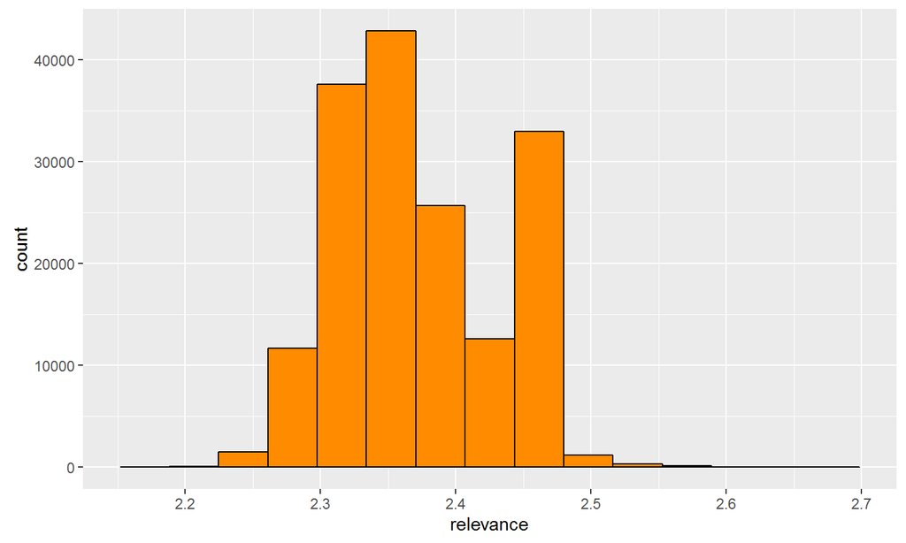

## Output Analysis Cont …

- Let us now investigate the features used in the model to see their affect on the result

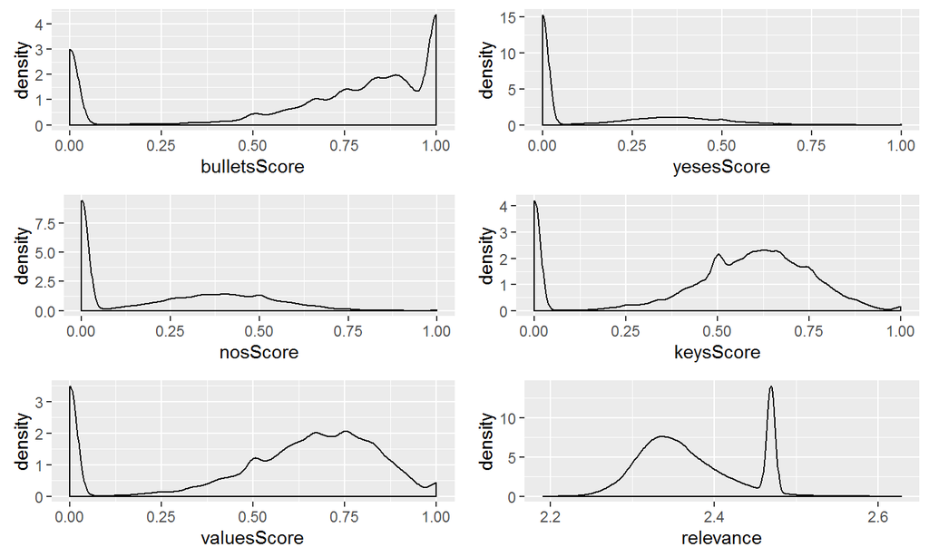

It seems that the builets score is one affects the outlier.

## Output Analysis Cont …

- Now, let us investigate more by seeing what each feature behave against relevance

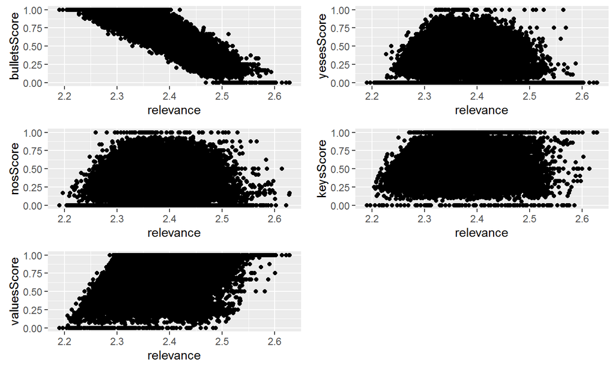